# Women at work

Data Handling: Import, Cleaning and Visualisation, Group project 2026

Lecturer

Dr. Aurélien Sallin

Published

October 2026

**Deadlines**: Please submit the intermediate version of your homework (Part 1) by **November 5th, 23:59**, and the full homework (Parts 1, 2 and 3) **by December 16th, 23:59**. Submission is done on Canvas.

**Points**: 82 in total. Part 1: 13 points, Part 2: 12 points, Part 3: 57 points. The World Bank API function in Part 2 is an optional bonus worth 3 points: bonus points can compensate for points lost elsewhere, up to the maximum of 82 points.

**Format**: A rendered Quarto HTML document using the official course template available on Canvas.

Ensure that:

- All variables are defined in the environment,
- Any required code (e.g., functions) is included in the document.
- Graphs print in the main text.

**Main text**: Use the main text to write your answers to the questions. **Be concise**: Answer each question in a few clear sentences. We do not read unnecessarily long answers: for example, general explanations that do not refer to your data, or printed output that is not discussed. Up to 8 of the 82 points can be deducted.

**Code**: Use code chunks to write and run your code. All code chunks must be visible in the document. The code must be spaced and readable (for inspiration, see the [Tidyverse style guide](https://style.tidyverse.org/))

**Important: We must be able to compile and render your Quarto document without errors.**

**Questions**: if you have any questions about the group project, please use the Q&A platform on Canvas. Questions by email will not be answered. The Q&A will close on December 12th, 23:59.

**Have fun!**

# Women at work

The question of women’s participation in the workforce has been widely discussed in Economics. On the one hand, economists are interested in explaining what motivates women to participate in the workforce, how women, and households in general, allocate their time between paid work and household chores, and what explains cross-country patterns in female participation. On the other hand, economists and society in general are looking to increase women’s participation, or at least to reduce barriers to entering work for women.

In the 1990s, Nobel Prize laureate Claudia Goldin studied women’s labor force participation as a function of economic development. Before Goldin’s research, it was widely assumed that economic growth automatically and steadily brings more women into the workforce. Using over 200 years of US data, Goldin showed that female labor market participation actually follows a **U-shaped curve**, which she explained theoretically and documented empirically, both across countries and in the economic history of the United States (Goldin (1995); Goldin (2006)).

In this group project, we revisit Goldin’s 1995 idea. The goal of the group project is to cover the full data pipeline as presented in the course. We will not make scientific claims about Goldin’s theory.

# Part 1: Importing data with R packages (intermediate submission)

To look at data on female labor force participation (“flfp”), we will import data from [Ilostat](https://ilostat.ilo.org/), the official statistics of the ILO (International Labor Organization). To measure economic development, we will import data from the World Bank. The next exercises guide you through the steps to import the data.

## Female labour force participation (ILO)

Import the “**Labour force participation rate by sex and age (%)**” for each available country by year from Ilostat, ILO using the **R-Package** [Rilostat](https://ilostat.github.io/Rilostat/index.html). Like Goldin (1995), we focus on older women, who have mostly finished school and raising young children: keep only **women aged 45 to 54**.

1. Explain which indicator you’ve chosen, and describe it briefly in words. 2 pts
2. Import the full series, i.e. all years available from 1950 to 2025. 3 pts

Go through the package vignette and have a look at the intro page. Search for the indicator using their TOC function (table of content) of all available data. Several indicators match the search: choose the one that lets you go furthest back in time, and justify your choice. Don’t forget to install the package before loading it.

```r
library(Rilostat)

toc <- get_ilostat_toc(
    search = "Labour force participation",
    quiet = TRUE
)
```

## GDP per capita (World Bank)

Retrieve yearly GDP per capita per country from the World Bank using their R package. We need time series that go as far back in time before 1990 as possible.

1. Explain which indicator you’ve chosen, and describe it briefly in words. 2 pts
2. Import the full series, i.e. all years available up to 2025. What is the oldest date available? 3 pts

Look for R packages that are wrappers for the World Bank data API (there are at least two). Search for the indicator using their search function. Several indicators match: choose one that (1) is expressed in the same currency for all countries, (2) is adjusted for inflation, so that you can compare years, and (3) goes as far back in time as possible. Justify your choice. The World Bank website may say that an indicator is “no longer available”. This concerns the website only: the API and the R packages still provide the data.

## Check and store the data

We have now extracted both datasets.

1. Check the number of rows of your two data frames. How many are they? Print the number of rows as an answer. 1 pt
2. Print the first 5 rows of each data frame. 1 pt
3. Store your data locally using `saveRDS` (the R format for R object). This will make your next steps faster, as you don’t have to load data from the API every time. 1 pt

# Part 2: Programming your own API functions (final submission)

In Part 1, you imported the data with R packages. Now you write your own function that calls the ILO API directly, and, as an optional bonus, one for the World Bank API. The data you saved in Part 1 let you check that your functions return the right numbers.

## Female labour force participation (ILO)

### Retrieve data using your own API wrapper

Retrieve the same series using your own API wrapper. Following the materials covered in lecture 6, create a function that

1. Directly imports data from the ILO’s SDMX REST API.
2. Allows for flexibly importing data. As arguments: the country, and the first and last year of the period. Make sure that it can also return all countries if no country is specified.
3. Returns an error message if the request does not come through.

Use the `httr2` package. Explain in 2–3 sentences how the URL sent by your function is built. 8 pts

1. Go to the ILO data explorer https://data.ilo.org, search “labour force participation”, filter the table (from 1950 to 2025, for each available country, and additional filters for women aged 45 to 54).
2. Click the “Developer API” button above the table: it shows the SDMX URL matching the filters (see also “API documentation” and “API query builder” on that page). Try out by clicking, copying the URL, then changing one piece at a time and see what happens
3. Use the [OECD’s API explainer](https://www.oecd.org/en/data/insights/data-explainers/2024/09/api.html). The OECD Data Explorer runs on the same software as data.ilo.org, so the URL syntax is the same.
4. Use the `.csv` format, as the `xml` or `json` format are less intuitive.
5. The opening of your code should look something like this:

```r
library(httr2)
get_ilodata <- function(country = "", year_from = 1950, year_to = 2025){
  ...
}
```

### Test your API

We now want to test whether your API returns the same data as the API wrapper from `Rilostat`.

1. Using a loop or a vectorized function (see lecture 2), test your API. Apply your function to the following countries: Switzerland, USA and Germany. Filter the year to 2023. Check the output. 2 pts
2. Then do the same using the `Rilostat` package. Compare the results. Are the results the same? 2 pts

## Bonus: GDP per capita (World Bank)

This section is optional. 3 bonus pts can compensate for points lost elsewhere, up to the maximum of 82 points.

### Import the data using your own API wrapper

Retrieve the same series using your own API wrapper. Following lecture 6, create a function that

1. Directly imports data from the World Bank’s REST API.
2. Allows for flexibly importing data. As arguments: the indicator of interest and the country.
3. Returns an error message if the request does not come through.

Using the `httr2` package and `resp_body_json()`.

1. DO NOT USE API360! This is an old version of the API, and is difficult to work with.
2. See the [World Bank API documentation](https://datahelpdesk.worldbank.org/knowledgebase/articles/898581-api-basic-call-structures). URLs look like

   ```
   https://api.worldbank.org/v2/country/COUNTRY/indicator/INDICATOR?format=json&date=START:END
   ```

   where `COUNTRY`, `INDICATOR`, `START` and `END` are the parts to replace. The country and the indicator are put in two different path segments. Try them in your browser first.
3. Add `format=json`, otherwise the API returns XML.
4. Check that you received all the observations you expected. The first element of the response may help.
5. An invalid indicator still returns status 200, with an error message instead of data.

### Test your API

As before, using a loop or a vectorized function (see lecture 2), test your API. Apply your function to the following countries: Switzerland, USA and Germany. Filter the year to 2023. Check the output. Then do the same using the `WDI` package. Are the results the same?

# Part 3: Cleaning, merging and analysing the data (final submission)

We investigate the relationship between women labor participation and GDP per capita. The objectives of Part 3 are the following:

1. Clean the data
2. Merge the different dataframes
3. Formulate a hypothesis to guide your research
4. Explore the data
5. Visualize the data to validate or invalidate your hypothesis.

You should have a R setup that looks like this:

```r
# Load libraries
library(ggplot2)
library(dplyr)
library(tidyr)

# Import data
df_ilo <- readRDS(
    "data/df_ilostat_womenparticipation.RDS"
)
df_wb <- readRDS(
    "data/df_WorldBank_gdp_capita.RDS"
)
```

## First data exploration

In his book *Statistics for Public Policy*, Jeremy G. Weber argues that one of the most important steps in working with data is… to **know your data.** By this, he means understanding key characteristics of the dataset. He highlights three essential aspects:

1. Know the **definitions** (for example, how are your indicators defined?)
2. Know the **units** (for example, are things measured in Euros, Swiss francs, or USD?)
3. Know the **quality** of your data. Conduct simple “smell tests” on key variables.

We can add two additional aspects:

4. Know the **unit of observation** (are the units we are observing countries, groups of countries, continents?)
5. Know the **time structure** (are we observing the same unit repeatedly over time, as in a panel, or different units at different times, as in a cross-section?)

Now explore the data frames you have imported.

1. Comment on the structure of your data frames and describe the types of variables they contain (for example, character, numeric, factor, date, etc.). 2 pts, 1 pt per dataset
2. Load the datasets. Briefly describe the content of each dataset according to the five key aspects described above. For aspect 3 (quality), perform two smell tests per dataset. 10 pts, 5 pts per dataset
- Answer very briefly.
- We deliberately do not define what a “smell test” is: deciding what to check is part of the exercise, and there is no single right answer.
- The function `skim` from the package `skimr` as well as the function `summarytools::dfSummary()` can be helpful to get a quick overview of the data.

## Data cleaning

Explore the data to identify the relevant variables for your analysis, making sure their formats and values are correct. Here are the restrictions we want to make on the data:

- Female labour force participation rate, for women aged 45 to 54, per country, between 1950 and 2025;
- GDP per capita in constant 2015 US dollars, per country, between 1960 and 2025. This variable must be also in LOG.

**Tasks**: For each dataset,

- Perform all the necessary cleaning steps, and clearly describe these steps in the code.
- Comment on the cleaning choices you made regarding the data.
- Keep only the variables needed for the analysis in your dataset (a minimal, working data frame).
- Summarize your variables of interest.

8 pts, 4 per dataset

- Dealing with potential missing values (`NAs`) are an important part of cleaning data. Make sure you document how you deal with them.
- Remember, our ultimate goal is to study the relationship between female labour force participation and economic development by comparing countries over time. Since you will need to merge the two datasets later, keep this in mind as you perform your cleaning steps.

## Merge the data

Merge the datasets in a single dataset that contains all the information that will be used for the subsequent analysis. Answer the following questions in text:

1. Which variable(s) will you use to perform the merge? 1 pt
2. Are there any additional cleaning steps required before merging the datasets, if any? 1 pt
3. What type of merge is appropriate (e.g., right join, left join, full join, etc.) in this case? 1 pt
4. What are the implications of your choice of merging method for your analysis? 2 pts
5. Are there any steps necessary in cleaning data after the merge? Pay attention to the missing values (if any) and explain how you deal with them. 1 pt

## Explore and visualize the data

In the following questions, there are different ways of giving a correct answer. As seen in the course, you might choose to present numbers in text, tables, or plots, or a mixture of these different methods. The materials draw on lectures 9-10. Choose the method you find the most effective to convey your answer. Remember to be concise.

### Trends in female labour force participation

Let’s start exploring the labor force participation variable. Answer the following questions:

1. How did female labour force participation evolve over time? Interpret the trend exactly. What should we be aware of/careful when interpreting the trend? 2 pts
2. Is this trend similar for all countries? What is your hypothesis? Confirm or reject your hypothesis using your data. 2 pts

### Trends in GDP per capita

Let’s now explore GDP per capita. Answer the following questions:

1. How did gdp per capita evolve over time? What should we be aware of/careful when interpreting the trend? 2 pts
2. Is this trend similar for rich and poor countries? Did the gap between them grow or shrink over time? 4 pts

## Goldin’s U-Shape theory

### Theoretical considerations

As introduced at the beginning, we’re interested in the relationship between economic development and female labour force participation at the country level. More specifically, we want to test the following hypotheses. Answer the following questions without using the data.

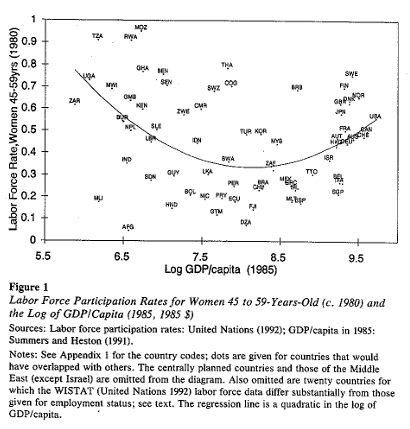

Figure 1: Female labour force participation and GDP per capita. Source: Goldin (1995).

1. As shown in Figure 1, Claudia Goldin shows a U-shaped correlation between GDP per capita and female labour force participation. This picture is her original graph from 1995. Comment on the graph and the expected correlation. 1 pt
2. Do you expect this relationship to have changed over time, for example between 1990 and 2020? 1 pt
3. Would you expect female labour force participation in Switzerland to be higher or lower than in its neighbours (Germany, France, Italy, Austria)? Why? 1 pt

### Reproducing Goldin’s graph

1. Explore the correlation with your data by reproducing Goldin’s graph (Figure 1) with our data. 4 pts
2. Compare your graph with Goldin’s: what differs between our data and hers? Give a final statement about your results. 2 pts
3. Like Goldin, we will use log of gdp as the main variable. Explain why. 1 pt
- Answer the questions visually. The goal of the Data Handling course is to explore the pipeline presented in lecture 1. We do not expect you to conduct inferential statistics.
- Your graph does not have to look **exactly** like Goldin’s. Our data are not the same as hers, and you should apply what we learned about data visualization in lectures 9-10. This is also a nice moment to pause and reflect on how much data science and data visualization have changed over the past 30 years (no need to write about it 📈😉).
- Use `geom_smooth()` to add a smoother to your scatter plot. For a quadratic curve, use a linear model and write the quadratic relationship in the `formula` argument.

#### Change over time

Look at the same correlation over time using a graph. Briefly comment. 3 pts

- Suggestion: focus on years 1970, 1990, 2010, 2020 to bin years together. This is better for analysis and readability.
- Did the U appear after 1970, or did the countries in the data change?

#### Female labour force participation in Switzerland 🇨🇭

1. Look at female labor participation in Switzerland over time and compare it to its neighbor countries. What do you notice? 2 pts
2. Look at the correlation between gdp and female labor participation for Switzerland and its neighboring countries. Can you conclude that they followed a U-Shape historical path? 3 pts
- Suggestion: focus on Italy, Germany, and France.

## Wrap up

### Your data story [Bonus reflection - perfect for your portfolio!]

If you were to publish this research (like in a blog post, data science portfolio, or LinkedIn article), what would be the compelling story you tell? Which graph would you choose, and how would you build your graph? Summarize your key findings and insights in max. 500 characters and one graph.

**Note**: This question is not graded but is valuable for developing your communication skills. It works particularly well as a group exercise: have each member brainstorm their own approach, then discuss together to identify the most effective and engaging story. Try not to use LLMs.

### Further steps 3 pts

Some further research showed issues with the U-shaped theory (e.g., Gaddis and Klasen (2014)). Based on your experience with this analysis, identify three specific ways to enhance this research project. Consider:

- Additional methodological approaches you could explore
- Further data quality checks or robustness tests we did not explore here
- Additional datasets that would strengthen your analysis
- New research questions or mechanisms worth investigating

**Note**: maximum 50 words in total for this exercise.

## References

Gaddis, Isis, and Stephan Klasen. 2014. “Economic Development, Structural Change, and Women’s Labor Force Participation: A Reexamination of the Feminization u Hypothesis.” *Journal of Population Economics* 27 (3): 639–81. https://doi.org/10.1007/s00148-013-0488-2.

Goldin, Claudia. 1995. “The u-Shaped Female Labor Force Function in Economic Development and Economic History.” In *Investment in Women’s Human Capital and Economic Development*, edited by T. Paul Schultz, 61–90. University of Chicago Press.

———. 2006. “The Quiet Revolution That Transformed Women’s Employment, Education, and Family.” *American Economic Review* 96 (2): 1–21.